# Machine Learning Assignment 1

## Introduction

This report examines the *Weight Lifting Exercises Dataset* to predict the manner in which the subjects did the excercise.

See website http://groupware.les.inf.puc-rio.br/har for more details about this dataset.

## Getting Data

The training and testing datasets were sourced from https://d396qusza40orc.cloudfront.net/predmachlearn/pml-training.csv and https://d396qusza40orc.cloudfront.net/predmachlearn/pml-testing.csv respectively.

```r
setwd("/Users/mengsam/Documents/R/Data Scientist/Machine Learning/Assignment/")

training <- read.csv("pml-training.csv",header=TRUE,na.strings=c("","NA","NULL"))

testing <- read.csv("pml-testing.csv",header=TRUE,na.strings=c("","NA","NULL"))
```

```r
dim(training)
```

```
## [1] 19622   160
```

## Data Cleansing

Two approaches were adapted to reduce the amount of predictors.

Firstly, NAs are observed in many columns of the training and testing datasets. These columns will be removed as they do not help in explaining the outcome. Similarly, metadata about the participants will also be removed.

```r
# removes columns with NAs
NonNA_Columns <- colnames(training[colSums(is.na(training)) == 0])
NonNA_NonMetadata <- NonNA_Columns[(8:60)]

# Revised training and testing dataset
training_v1 <- training[NonNA_NonMetadata]

dim(training_v1)
```

```
## [1] 19622    53
```

Secondly, highly correlated variables will be removed to avoid multicollinearity.

```r
# load required packages
library(caret)
library(rattle)
# computes correlation
Matrix_Correl <- cor(na.omit(training_v1[sapply(training_v1, is.numeric)]))

# Find highly correlated variables
High_Corr_Matrix <- findCorrelation(Matrix_Correl, cutoff = .90, verbose = FALSE)

# Revised training and testing dataset
training_v2 <- training_v1[,-High_Corr_Matrix]

dim(training_v2)
```

```
## [1] 19622    46
```

The revised dataset will now be used in the modelling.

## Data Analysis

```r
# Create training and test datasets. This data slicing will allow us to perform cross validation when developing and testing the performance of the models.
inTrain <- createDataPartition(training_v2$classe,p=0.7,list=FALSE)
training_data <- training_v2[inTrain,]
testing_data <- training_v2[-inTrain,]
```

Predictive Tree Models taught in class will be used to classify variables into groups.

```r
# rpart constructs trees based on the outcome and predictors
set.seed(11111)
modFit_rpart <- train(classe~.,data=training_data,method="rpart")
modFit_rpart$finalModel
```

```
## n= 13737
##
## node), split, n, loss, yval, (yprob)
##       * denotes terminal node
##
##  1) root 13737 9831 A (0.28 0.19 0.17 0.16 0.18)
##    2) pitch_forearm< -26.65 1218   54 A (0.96 0.044 0 0 0) *
##    3) pitch_forearm>=-26.65 12519 9777 A (0.22 0.21 0.19 0.18 0.2)
##      6) magnet_belt_y>=555.5 11487 8747 A (0.24 0.23 0.21 0.18 0.15)
##       12) magnet_dumbbell_y< 436.5 9584 6905 A (0.28 0.18 0.24 0.17 0.13)
##         24) roll_forearm< 122.5 6047 3633 A (0.4 0.18 0.19 0.15 0.091) *
##         25) roll_forearm>=122.5 3537 2333 C (0.075 0.18 0.34 0.22 0.18)
##           50) accel_forearm_x>=-108.5 2493 1539 C (0.086 0.22 0.38 0.091 0.22) *
##           51) accel_forearm_x< -108.5 1044  484 D (0.048 0.082 0.24 0.54 0.094) *
##       13) magnet_dumbbell_y>=436.5 1903 1003 B (0.032 0.47 0.035 0.21 0.25) *
##      7) magnet_belt_y< 555.5 1032  183 E (0.0019 0.0019 0.00097 0.17 0.82) *
```

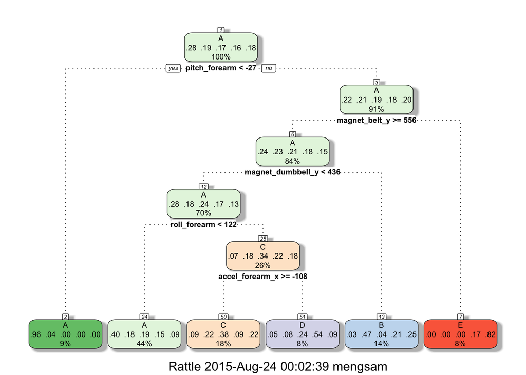

```r
fancyRpartPlot(modFit_rpart$finalModel)
```

```r
# Cross validation
predictions <- predict(modFit_rpart,testing_data)
predictions_matrix = with(testing_data,table(predictions,classe))
1 - sum(diag(predictions_matrix))/sum(as.vector(predictions_matrix))
```

```
## [1] 0.5059
```

The high error rate shows the poor modelling performance.

```r
# rf is an extension of bagging on classification/regression trees and will be used to see whether a lower out of sample error can be achieved.
set.seed(11111)
modFit_rf <- train(classe~.,data=training_data,method="rf")
modFit_rf
```

```
## Random Forest
##
## 13737 samples
##    45 predictor
##     5 classes: 'A', 'B', 'C', 'D', 'E'
##
## No pre-processing
## Resampling: Bootstrapped (25 reps)
##
## Summary of sample sizes: 13737, 13737, 13737, 13737, 13737, 13737, ...
##
## Resampling results across tuning parameters:
##
##   mtry  Accuracy  Kappa   Accuracy SD  Kappa SD
##    2    0.9871    0.9837  0.001995     0.002524
##   23    0.9885    0.9855  0.001856     0.002350
##   45    0.9784    0.9726  0.004135     0.005235
##
## Accuracy was used to select the optimal model using  the largest value.
## The final value used for the model was mtry = 23.
```

```r
# Cross validation
predictions <- predict(modFit_rf,testing_data)
predictions_matrix_rf = with(testing_data,table(predictions,classe))
1 - sum(diag(predictions_matrix_rf))/sum(as.vector(predictions_matrix_rf))
```

```
## [1] 0.009516
```

The low error rate shows the model high predictive capability.

## Predictions

We will now use the derived random forest model to predict the outcome using the data from the test set.

```r
answer <- predict(modFit_rf,testing)
answer
```

```
##  [1] B A B A A E D B A A B C B A E E A B B B
## Levels: A B C D E
```